# Data Pre-processing

Zhen Liu

2018/2/1

```r
library(haven)
Rawdata<- read_sav("~/Desktop/stat450/seniorworkers/senior worker/Data/Data-NFEHRS_revised.sav")  #1247
```

### 1. Check Response

```r
summary(Rawdata$num_use)
```

```
##    Min. 1st Qu.  Median    Mean 3rd Qu.    Max.
##   1.000   1.000   1.667   1.959   2.500   7.000
```

```r
nrow(Rawdata[Rawdata$num_use==7,])  ##why there is a '7'....????
```

```
## [1] 1
```

The max of num_use is 5 so I guessed 7 may be a wrong input. After delete this observation(num_use=7):

```r
newdata<- Rawdata[Rawdata$num_use!=7,]  #1246
par(mfrow=c(2,2))
#1)skill_num
summary(newdata$num_use)
```

```
##    Min. 1st Qu.  Median    Mean 3rd Qu.    Max.
##   1.000   1.000   1.667   1.955   2.500   5.000
```

```r
qqnorm(newdata$num_use)
qqline(newdata$num_use)

#2) skill_lit
summary(newdata$liter_use)
```

```
##    Min. 1st Qu.  Median    Mean 3rd Qu.    Max.
##   1.000   1.333   2.083   2.267   3.146   5.000
```

```r
qqnorm(newdata$liter_use)
qqline(newdata$liter_use)

#3) test_num
summary(newdata$pvnumM)
```

```
##    Min. 1st Qu.  Median    Mean 3rd Qu.    Max.
##   104.9   213.9   243.7   242.0   270.7   380.7
```

```r
qqnorm(newdata$pvnumM)
qqline(newdata$pvnumM)

#4) test_lit
summary(newdata$pvlitM)
```

```
##    Min. 1st Qu.  Median    Mean 3rd Qu.    Max.
##   119.3   226.1   253.7   250.4   275.6   372.1
```

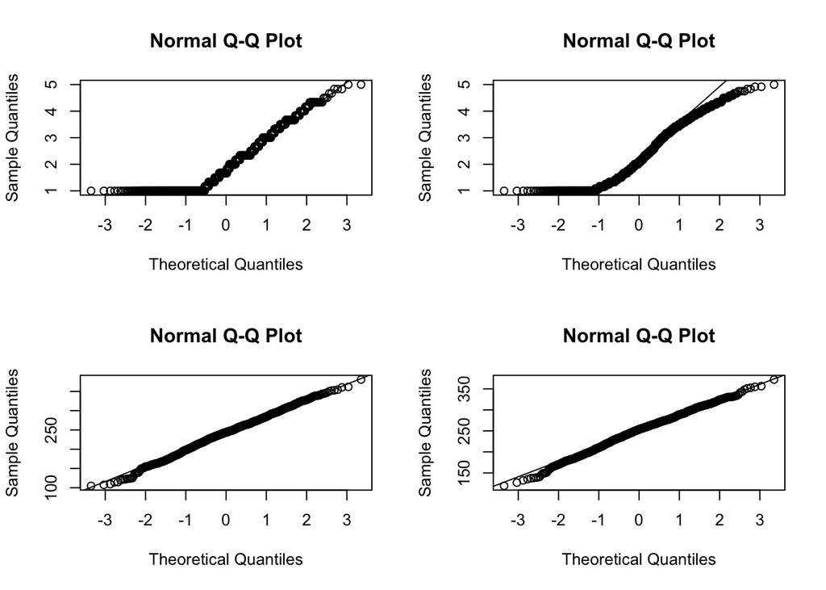

```r
qqnorm(newdata$pvlitM)
qqline(newdata$pvlitM)
```

The top left and top right Q-Q plot are not on a straight line. We might need some further transformation on the responses(num_use, liter_use)

The bottom left and bottom right Q-Q plot seem on a straight line so it is fair to say that the two responses(pvnumM, pvlitM) of our sample are normal distributed. The assumption of linear regression is statisfied.

### 2. Missing Value

```r
nrow(newdata[is.na(newdata$Mgr),]) #501
nrow(newdata[is.na(newdata$GENDER_R),]) #0
nrow(newdata[is.na(newdata$ED_Level),]) #0
nrow(newdata[is.na(newdata$EMPloyed),]) #0
nrow(newdata[is.na(newdata$Full_part),]) #0
nrow(newdata[is.na(newdata$Years_wk),]) #0
nrow(newdata[is.na(newdata$pub_priv),]) #39
nrow(newdata[is.na(newdata$NFE12),]) #0
nrow(newdata[is.na(newdata$FNFAET12),]) #0
nrow(newdata[is.na(newdata$FNFE12JR),]) #0
nrow(newdata[is.na(newdata$FNFAET12JR),]) #0
nrow(newdata[is.na(newdata$FNFAET12NJR),]) #0
nrow(newdata[is.na(newdata$NFEHRS),]) #0
```

There are 501 missing value in the ‘Mgr’ column, which is more than 40% of the total number of the observations. I would suggest that progressing our regression analysis without this variable first.

There are 39 missing value in the ‘pub_priv’.

```r
table(newdata$pub_priv)
```

```
##
##    1    2
## 1062  145
```

From the table above, 1062 of the observations are from private sector while 145 of them are from Public sector.

I’ll create a dataset called ‘data_priv’, which only contains the employers in private sector.

```r
newdata$pub_priv <- factor(newdata$pub_priv)
data_priv <- newdata[newdata$pub_priv ==1 & (!is.na(newdata$pub_priv)), ] #1062
```

I’ll create a dataset called ‘data_both’, which contains the employers in private sector or in public sector(that is, deleting the rows who have missing value).

```r
data_both <- newdata[!is.na(newdata$pub_priv), ] #1207
```